# Visualization and Exploratory Data Analysis in Python

## Regression Analysis – Multiple Linear Regression (MLR)

"Multiple linear regression analysis is essentially similar to the simple linear model, with the exception that multiple independent variables are used in the model. The mathematical representation of multiple linear regression:

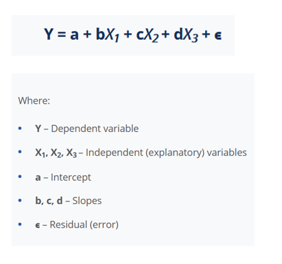

Multiple linear regression follows the same conditions as the simple linear model. However, since there are several independent variables in multiple linear analysis, there is another mandatory condition for the model:

**Non-collinearity**: Independent variables should show a minimum of correlation with each other. If the independent variables are highly correlated with each other, it will be difficult to assess the true relationships between the dependent and independent variables".

Source: https://corporatefinanceinstitute.com/resources/knowledge/finance/regression-analysis/

We will develope MLR model with five predictors ('DEM', 'Slope', 'MAT', 'MAP','NDVI') to explain variability soil organic carbon

### Define Xs and Y variables

```python
Xm =mf[['DEM', 'Slope', 'MAT', 'MAP','NDVI']].values
y = mf[['SOC']].values
```

### Split data to training and test data

```python
from sklearn.model_selection import train_test_split

x_train, x_test, y_train, y_test = train_test_split(Xm, y, test_size=0.2, random_state=0)
```

### Standardize features (predictors - x)¶

```python
from sklearn import preprocessing

x_train = preprocessing.scale(x_train)
x_test = preprocessing.scale(x_test)
```

### Train a MLR model

```python
from sklearn.linear_model import LinearRegression

mlr = LinearRegression()
mlr.fit(x_train, y_train)
```

```
LinearRegression()
```

### Get Coefficents of MLR model

```python
pred_mlr = pd.DataFrame(['DEM', 'Slope', 'MAT', 'MAP','NDVI'])
coeff = pd.DataFrame(mlr.coef_, index=['Co-efficient']).transpose()
pd.concat([pred_mlr,coeff], axis=1, join='inner')
```

| 0 | Co-efficient |
| --- | --- |

### Create a R like suumary Output (source: https://stackoverflow.com/questions/27928275/find-p-value-significance-in-scikit-learn-linearregression)

```python
from scipy import stats

params = np.append(mlr.intercept_,mlr.coef_)
predictions = mlr.predict(x_train)

newX = pd.DataFrame({"Constant":np.ones(len(x_train))}).join(pd.DataFrame(x_train))
MSE = (sum((y_train-predictions)**2))/(len(newX)-len(newX.columns))

# Note if you don't want to use a DataFrame replace the two lines above with
# newX = np.append(np.ones((len(X),1)), X, axis=1)
# MSE = (sum((y-predictions)**2))/(len(newX)-len(newX[0]))

var_b = MSE*(np.linalg.inv(np.dot(newX.T,newX)).diagonal())
sd_b = np.sqrt(var_b)
ts_b = params/ sd_b

p_values =[2*(1-stats.t.cdf(np.abs(i),(len(newX)-len(newX[0])))) for i in ts_b]

sd_b = np.round(sd_b,3)
ts_b = np.round(ts_b,3)
p_values = np.round(p_values,3)
params = np.round(params,4)

myDF3 = pd.DataFrame()
myDF3["Coefficients"],myDF3["Standard Errors"],myDF3["t values"],myDF3["Probabilities"] = [params,sd_b,ts_b,p_values]
print(myDF3)
```

```
   Coefficients  Standard Errors  t values  Probabilities
0        6.2055            0.185    33.512            NaN
1       -0.0468            0.430    -0.109            NaN
2        0.3430            0.303     1.133            NaN
3       -1.1218            0.352    -3.185            NaN
4        1.1700            0.360     3.251            NaN
5        1.7316            0.359     4.829            NaN
```

### Training Statistics of MLR model

```python
import sklearn.metrics as metrics

y_train_mlr=mlr.predict(x_train)
```

```python
explained_variance=metrics.explained_variance_score(y_train, y_train_mlr)
mean_absolute_error=metrics.mean_absolute_error(y_train, y_train_mlr)
mse = metrics.mean_squared_error(y_train, y_train_mlr)
median_absolute_error = metrics.median_absolute_error(y_train, y_train_mlr)
r2 = metrics.r2_score(y_train, y_train_mlr)
```

```python
print('Explained_variance or R2: ', round(explained_variance,4))
print('MAE: ', round(mean_absolute_error,4))
print('MSE: ', round(mse,4))
print('RMSE: ', round(np.sqrt(mse),4))
```

```
Explained_variance or R2:  0.4064
MAE:  2.7994
MSE:  15.4298
RMSE:  3.9281
```

## MLR with Pingouin

```python
import numpy as np
import pingouin as pg

pg.linear_regression(mf[['DEM', 'Slope', 'MAT', 'MAP','NDVI']], mf['SOC'])
```

| names | coef | se | T | pval | r2 | adj_r2 | CI[2.5%] | CI[97.5%] |
| --- | --- | --- | --- | --- | --- | --- | --- | --- |

### Regression analysis with "statsmodels"¶

"statsmodels" is a Python module that provides classes and functions for the estimation of many different statistical models, as well as for conducting statistical tests, and statistical data exploration. An extensive list of result statistics are available for each estimator. The results are tested against existing statistical packages to ensure that they are correct. The package is released under the open source Modified BSD (3-clause) license. The online documentation is hosted at statsmodels.org.

### Multiple Linear Regression (MLR)

```python
import statsmodels.api as sm
import statsmodels.formula.api as smf
from statsmodels.graphics.api import abline_plot

mlr_results = smf.ols('SOC ~ DEM + Slope + MAT + MAP + NDVI', data=df).fit()
```

```python
print(mlr_results.summary())
```

```
                            OLS Regression Results
==============================================================================
Dep. Variable:                    SOC   R-squared:                       0.416
Model:                            OLS   Adj. R-squared:                  0.411
Method:                 Least Squares   F-statistic:                     80.41
Date:                Sun, 18 Apr 2021   Prob (F-statistic):           1.19e-63
Time:                        00:06:50   Log-Likelihood:                -1573.4
No. Observations:                 570   AIC:                             3159.
Df Residuals:                     564   BIC:                             3185.
Df Model:                           5
Covariance Type:            nonrobust
==============================================================================
                 coef    std err          t      P>|t|      [0.025      0.975]
------------------------------------------------------------------------------
Intercept      0.8946      1.615      0.554      0.580      -2.278       4.067
DEM           -0.0001      0.000     -0.271      0.786      -0.001       0.001
Slope          0.0945      0.056      1.690      0.092      -0.015       0.204
MAT           -0.2578      0.075     -3.451      0.001      -0.405      -0.111
MAP            0.0052      0.001      3.545      0.000       0.002       0.008
NDVI          10.7575      1.883      5.714      0.000       7.059      14.456
==============================================================================
Omnibus:                      128.279   Durbin-Watson:                   1.281
Prob(Omnibus):                  0.000   Jarque-Bera (JB):              306.549
Skew:                           1.158   Prob(JB):                     2.72e-67
Kurtosis:                       5.746   Cond. No.                     2.37e+04
==============================================================================

Notes:
[1] Standard Errors assume that the covariance matrix of the errors is correctly specified.
[2] The condition number is large, 2.37e+04. This might indicate that there are
strong multicollinearity or other numerical problems.
```

## Generalized Linear Models (GLM)

In statistics, the generalized linear model (GLM) is a flexible generalization of ordinary linear regression that allows for response variables that have error distribution models other than a normal distribution. The GLM generalizes linear regression by allowing the linear model to be related to the response variable via a link function and by allowing the magnitude of the variance of each measurement to be a function of its predicted value (Wikipedia, 2019).

The distribution families currently implemented in statsmodels are:

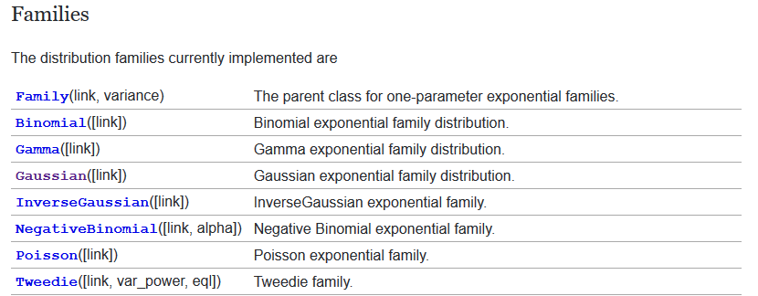

### GLM (Gaussian Family) with statsmodels

If outcome is continuous and unbounded, then the most "default" choice is the Gaussian distribution (a.k.a. normal distribution), i.e. the standard linear regression (unless you use other link function then the default identity link)(Source).

```python
glm_gaussian = sm.formula.glm('SOC ~ DEM + Slope + MAT + MAP + NDVI',
                       family=sm.families.Gaussian(), data=df).fit()
```

```python
print(glm_gaussian.summary())
```

```
                 Generalized Linear Model Regression Results
==============================================================================
Dep. Variable:                    SOC   No. Observations:                  570
Model:                            GLM   Df Residuals:                      564
Model Family:                Gaussian   Df Model:                            5
Link Function:               identity   Scale:                          14.784
Method:                          IRLS   Log-Likelihood:                -1573.4
Date:                Sun, 18 Apr 2021   Deviance:                       8338.1
Time:                        00:06:50   Pearson chi2:                 8.34e+03
No. Iterations:                     3
Covariance Type:            nonrobust
==============================================================================
                 coef    std err          z      P>|z|      [0.025      0.975]
------------------------------------------------------------------------------
Intercept      0.8946      1.615      0.554      0.580      -2.271       4.060
DEM           -0.0001      0.000     -0.271      0.786      -0.001       0.001
Slope          0.0945      0.056      1.690      0.091      -0.015       0.204
MAT           -0.2578      0.075     -3.451      0.001      -0.404      -0.111
MAP            0.0052      0.001      3.545      0.000       0.002       0.008
NDVI          10.7575      1.883      5.714      0.000       7.067      14.448
==============================================================================
```

```python
print('Parameters: ', glm_gaussian.params)
print('T-values: ', glm_gaussian.tvalues)
```

```
Parameters:  Intercept     0.894583
DEM          -0.000133
Slope         0.094482
MAT          -0.257827
MAP           0.005239
NDVI         10.757545
dtype: float64
T-values:  Intercept    0.553910
DEM         -0.271273
Slope        1.690318
MAT         -3.450864
MAP          3.545001
NDVI         5.713611
dtype: float64
```

# GLM with H20-Ai

H2O is an open source, in-memory, distributed, fast, and scalable machine learning and predictive analytics platform that allows you to build machine learning models on big data and provides easy productionalization of those models in an enterprise environment. It’s core code is written in Java and can read data in parallel from a distributed cluster and also from local cluster. H2O allows access to all the capabilities of H2O from an external program or script via JSON over HTTP. The Rest API is used by H2O’s web interface (Flow UI), R binding (H2O-R), and Python binding (H2O-Python).

In this tutorial will show how to implement a h2o-GLM in Pythom. Use following steps to install h20 in Python in PyGeo Envrionment:

### Install the latest version of h2o

- **First Installation of dependencies of h2o-3**

pip install requests pip install tabulate pip install "colorama>=0.3.8" pip install future

- **Install h2o-3**

pip install -f http://h2o-release.s3.amazonaws.com/h2o/latest_stable_Py.html h2o

- **Check h2o installation**

(E:\PyGeo) C:\Users\zua3>python Python 3.8.8 | packaged by conda-forge | (default, Feb 20 2021, 15:50:08) [MSC v.1916 64 bit (AMD64)] on win32 Type "help", "copyright", "credits" or "license" for more information.

$ import h2o

$ h2o.init()

```python
import h2o
h2o.init()
```

```
Checking whether there is an H2O instance running at http://localhost:54321 ..... not found.
Attempting to start a local H2O server...
; Java HotSpot(TM) 64-Bit Server VM (build 25.201-b09, mixed mode)
  Starting server from E:\DSM\Lib\site-packages\h2o\backend\bin\h2o.jar
  Ice root: C:\Users\Public\Documents\Wondershare\CreatorTemp\tmpbhzsb4a9
  JVM stdout: C:\Users\Public\Documents\Wondershare\CreatorTemp\tmpbhzsb4a9\h2o_zua3_started_from_python.out
  JVM stderr: C:\Users\Public\Documents\Wondershare\CreatorTemp\tmpbhzsb4a9\h2o_zua3_started_from_python.err
  Server is running at http://127.0.0.1:54377
Connecting to H2O server at http://127.0.0.1:54377 ... successful.
```

| H2O_cluster_uptime: | 05 secs |
| --- | --- |
| H2O_cluster_timezone: | America/New_York |
| H2O_data_parsing_timezone: | UTC |
| H2O_cluster_version: | 3.32.1.1 |
| H2O_cluster_version_age: | 23 days |
| H2O_cluster_name: | H2O_from_python_zua3_ci1z9n |
| H2O_cluster_total_nodes: | 1 |
| H2O_cluster_free_memory: | 14.18 Gb |
| H2O_cluster_total_cores: | 8 |
| H2O_cluster_allowed_cores: | 8 |
| H2O_cluster_status: | accepting new members, healthy |
| H2O_connection_url: | http://127.0.0.1:54377 |
| H2O_connection_proxy: | {"http": null, "https": null} |
| H2O_internal_security: | False |
| H2O_API_Extensions: | Amazon S3, Algos, AutoML, Core V3, TargetEncoder, Core V4 |
| Python_version: | 3.8.8 final |

### Import data to the h20 cluster

```python
df_h = h2o.import_file("E:/Python Lesson/Soil_data.csv")
```

```
Parse progress: |█████████████████████████████████████████████████████████| 100%
```

### Convert NLCD as factors

The "NLCD_DES" column is really categorical, not numeric, so it need to covert to factors

```python
df_h['NLCD_DES'] = df_h['NLCD_DES'].asfactor()
```

### Define X (predictors or features) and Y (response)

```python
predictors = ['DEM', 'Slope', 'MAT', 'MAP','NDVI', 'NLCD_DES']
response_col = "SOC"
```

### Define GLM (gaussian) models

```python
from h2o.estimators.glm import H2OGeneralizedLinearEstimator

glm_model = H2OGeneralizedLinearEstimator(family= "gaussian",
                                          lambda_ = 0,
                                          compute_p_values = True)
```

### Train the model

```python
glm_model.train(predictors, response_col, training_frame= df_h)
```

```
glm Model Build progress: |███████████████████████████████████████████████| 100%
```

### Print the Coefficients table

```python
glm_model._model_json['output']['coefficients_table']
```

```
Coefficients: glm coefficients
```

| names | coefficients | std_error | z_value | p_value | standardized_coefficients |
| --- | --- | --- | --- | --- | --- |

### Retrieve a graphical plot of the standardized coefficient magnitudes

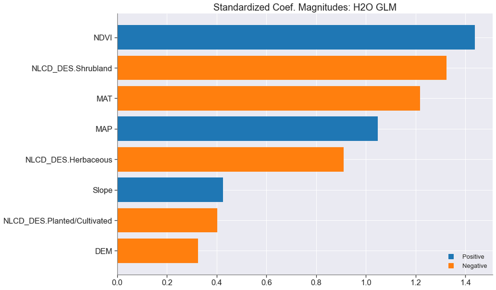

```python
glm_model.std_coef_plot()
```

# Basic regression with TensorFlow

"TensorFlow is an end-to-end open source platform for machine learning. It has a comprehensive, flexible ecosystem of tools, libraries and community resources that lets researchers push the state-of-the-art in ML and developers easily build and deploy ML powered applications". It has CPU and GUP version. If you want to run this tutorial with GUP version of TensorFlow you need following prerequisites in your system:

**Software requirements**

The following NVIDIA® software must be installed on your system:

- NVIDIA® GPU drivers —CUDA® 11.0 requires 450.x or higher.
- CUDA® Toolkit —TensorFlow supports CUDA® 11 (TensorFlow >= 2.4.0)
- CUPTI ships with the CUDA® Toolkit.
- cuDNN SDK 8.0.4 cuDNN versions).
- (Optional) TensorRT 6.0 to improve latency and throughput for inference on some models.

Follow the instruction of Jeff Heaton in his [YouTube video](https://www.youtube.com/watch?v=-Q6SM_usn84&t=925s)

(E:\DSM) C:\Users\zua3>pip install tensorflow-gpu

It will take 5-10 mins to install, depending on internet speed.

Check TensorFlow GPU installation

(E:\DSM) C:\Users\zua3>python Python 3.8.8 | packaged by conda-forge | (default, Feb 20 2021, 15:50:08) [MSC v.1916 64 bit (AMD64)] on win32 Type "help", "copyright", "credits" or "license" for more information.

import tensorflow as tf

2021-04-12 15:53:16.395257: I tensorflow/stream_executor/platform/default/dso_loader.cc:49] Successfully opened dynamic library cudart64_110.dll

This sections follows the tutorial of [Basic regression: Predict fuel efficiency](https://www.tensorflow.org/tutorials/keras/regression) by Google

```python
import tensorflow as tf

from tensorflow import keras
from tensorflow.keras import layers
from tensorflow.keras.layers.experimental import preprocessing

print(tf.__version__)
```

```
2.4.1
```

### Convert NLCD as factors

The "NLCD_DES" column is really categorical, not numeric, so iSo convert that to a one-hot with **pd.get_dummies**:

```python
# Create a new data set
dataset=df[['SOC', 'DEM', 'Slope','MAP', 'MAT','NDVI', 'NLCD_DES']]
```

```python
import numpy as np
import pandas as pd

dataset = pd.get_dummies(dataset, columns=['NLCD_DES'], prefix='', prefix_sep='')
dataset.tail()
```

| SOC | DEM | Slope | MAP | MAT | NDVI | Forest | Herbaceous | Planted/Cultivated | Shrubland |
| --- | --- | --- | --- | --- | --- | --- | --- | --- | --- |

### Split the data into train and test

Now split the dataset into a training set and a test set.

Use the test set in the final evaluation of our models.

```python
train_dataset = dataset.sample(frac=0.8, random_state=0)
test_dataset = dataset.drop(train_dataset.index)
```

### Split features from labels

Separate the target value (y), the "label", from the features. This label is the value that you will train the model to predict.

```python
# Response or traget or Y

train_features = train_dataset.copy()
test_features = test_dataset.copy()

## Features or predictors or labels or X

train_labels = train_features.pop('SOC')
test_labels = test_features.pop('SOC')
```

### Normalization

In the table of statistics it's easy to see how different the ranges of each feature are.

```python
train_dataset.describe().transpose()[['mean', 'std']]
```

|  | mean | std |
| --- | --- | --- |

The preprocessing.Normalization layer is a clean and simple way to build that preprocessing into your model.

The first step is to create the layer:

```python
normalizer = preprocessing.Normalization()
```

Then .adapt() it to the data:

```python
normalizer.adapt(np.array(train_features))
```

```python
first = np.array(train_features[:1])

with np.printoptions(precision=2, suppress=True):
  print('First example:', first)
  print()
  print('Normalized:', normalizer(first).numpy())
```

```
First example: [[799.44   1.71 530.82  12.32   0.44   0.     1.     0.     0.  ]]

Normalized: [[-1.09 -0.64  0.19  0.84  0.06 -0.49  1.48 -0.5  -0.64]]
```

### Simple Linear regression with TensorFlow

Start with a single-variable linear regression, to predict SOC from NDVI Training a model with tf.keras typically starts by defining the model architecture.

In this case use a keras.Sequential model. This model represents a sequence of steps. In this case there are two steps:

- Normalize the input NDVI.
- Apply a linear transformation (y = mx + b) to produce 1 output using **layers.Dense**.

The number of inputs can either be set by the **input_shape argument*, or automatically when the model is run for the first time.

First create the NDVI Normalization layer:

```python
NDVI = np.array(train_features['NDVI'])

NDVI_normalizer = preprocessing.Normalization(input_shape=[1,])
NDVI_normalizer.adapt(NDVI)
```

Build the sequential model:

```python
slr_model = tf.keras.Sequential([
    NDVI_normalizer,
    layers.Dense(units=1)
])

NDVI_model.summary()
```

[output not shown]

Once the model is built, configure the training procedure using the **Model.compile()** method. The most important arguments to compile are the **loss** and the **optimizer** since these define what will be optimized (**mean_absolute_error**) and how (using the **optimizers.Adam**).

```python
slr_model.compile(
    optimizer=tf.optimizers.Adam(learning_rate=0.1),
    loss='mean_absolute_error')
```

Once the training is configured, use **Model.fit()** to execute the training:

```python
%%time
history = slr_model.fit(
    train_features['NDVI'], train_labels,
    epochs=100,
    # suppress logging
    verbose=0,
    # Calculate validation results on 20% of the training data
    validation_split = 0.2)
```

```
Wall time: 12.7 s
```

Visualize the model's training progress using the stats stored in the history object.

```python
hist = pd.DataFrame(history.history)
hist['epoch'] = history.epoch
hist.tail()
```

| loss | val_loss | epoch |
| --- | --- | --- |

```python
import matplotlib.pyplot as plt
import seaborn as sns

def plot_loss(history):
  plt.plot(history.history['loss'], label='loss')
  plt.plot(history.history['val_loss'], label='val_loss')
  plt.ylim([0, 10])
  plt.xlabel('Epoch')
  plt.ylabel('Error [NDVI]')
  plt.legend()
  plt.grid(True)
```

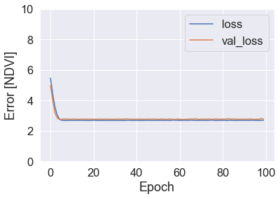

```python
plot_loss(history)
```

### Prediction at Test Locations

```python
SLR_pred = slr_model.predict(test_features['NDVI'])
```

```python
SLR_Pred_df = pd.DataFrame({'Observed': test_labels.values.flatten(), 'Predicted': SLR_pred.flatten()})
SLR_Pred_df.head()
```

| Observed | Predicted |
| --- | --- |

### 1:1 Plot- Observed vs Predicted Values

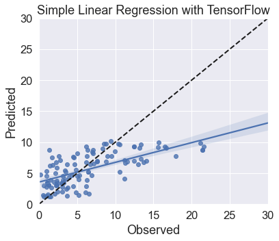

```python
import matplotlib.pyplot as plt
import seaborn as sns

plt.figure(figsize=(6, 5))
ax = sns.regplot(x="Observed", y="Predicted", data=SLR_Pred_df)
ax.set_ylim(0,30)
ax.set_xlim(0,30)
ax.plot([0, 30], [0, 30], 'k--', lw=2)
plt.title('Simple Linear Regression with TensorFlow',fontsize=18)
```

```python
test_results = {}

test_results['SLR_model'] = slr_model.evaluate(
    test_features['NDVI'],
    test_labels, verbose=0)
```

```python
test_results
```

```
{'SLR_model': 3.0481503009796143}
```

```python
import sklearn.metrics as metrics

slr_mse = metrics.mean_squared_error(SLR_pred, test_labels)
slr_rmse = np.sqrt(metrics.mean_squared_error(SLR_pred, test_labels))
```

```python
print("SLR score (MSE): {}".format(slr_mse))
print("SLR score (RMSE): {}".format(slr_rmse))
```

```
SLR score (MSE): 19.462974606839058
SLR score (RMSE): 4.411686141016727
```

### Multiple Linear Regression in TensorFlow

You can use an almost identical setup to make predictions based on multiple features. This model still does the same **y = mx+b**, except that **m** is a matrix and **b** is a vector.

```python
mlr_model = tf.keras.Sequential([
    normalizer,
    layers.Dense(units=1)
])
```

When you call the model it's weight matrices will be built. Now you can see that the kernel (the in ) has a shape of (9,1).

```python
mlr_model.layers[1].kernel
```

```
<tf.Variable 'dense_4/kernel:0' shape=(9, 1) dtype=float32, numpy=
array([[-0.1923396 ],
       [ 0.6320157 ],
       [ 0.43520057],
       [ 0.23506916],
       [ 0.45226872],
       [-0.29988828],
       [ 0.5263705 ],
       [-0.01880282],
       [ 0.5988151 ]], dtype=float32)>
```

Use the same compile and fit calls as for the single input NDVI model:

```python
mlr_model.compile(
    optimizer=tf.optimizers.Adam(learning_rate=0.1),
    loss='mean_absolute_error')
```

```python
%%time
history = mlr_model.fit(
    train_features, train_labels,
    epochs=100,
    # suppress logging
    verbose=0,
    # Calculate validation results on 20% of the training data
    validation_split = 0.2)
```

```
Wall time: 15.6 s
```

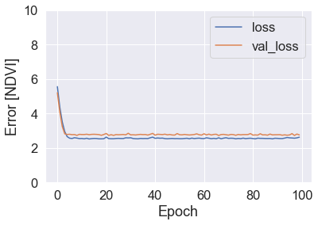

```python
plot_loss(history)
```

### MLR prediction test locatioon

```python
MLR_pred = mlr_model.predict(test_features)
```

```python
MLR_Pred_df = pd.DataFrame({'Observed': test_labels.values.flatten(), 'Predicted': MLR_pred.flatten()})
MLR_Pred_df.head()
```

| Observed | Predicted |
| --- | --- |

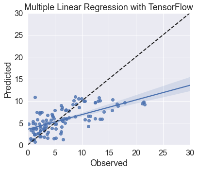

```python
import matplotlib.pyplot as plt
import seaborn as sns

plt.figure(figsize=(6, 5))
ax = sns.regplot(x="Observed", y="Predicted", data=MLR_Pred_df)
ax.set_ylim(0,30)
ax.set_xlim(0,30)
ax.plot([0, 30], [0, 30], 'k--', lw=2)
plt.title('Multiple Linear Regression with TensorFlow',fontsize=18)
```

```python
import sklearn.metrics as metrics

mlr_mse = metrics.mean_squared_error(MLR_pred, test_labels)
mlr_rmse = np.sqrt(metrics.mean_squared_error(MLR_pred, test_labels))
```

```python
print("MLR score (MSE): {}".format(mlr_mse))
print("MLR score (RMSE): {}".format(mlr_rmse))
```

```
MLR score (MSE): 19.039551754213985
MLR score (RMSE): 4.363433482272187
```

```python
test_results['MLR_model'] = mlr_model.evaluate(
    test_features,
    test_labels, verbose=0)
```

```python
pd.DataFrame(test_results, index=['Mean absolute error [SOC]']).T
```

|  | Mean absolute error [SOC] |
| --- | --- |

### Lift Chart

(source: https://sites.wustl.edu/jeffheaton/t81-558/)

To generate a lift chart, perform the following activities:

```python
def chart_regression(pred, y, sort=True):
    t = pd.DataFrame({'pred': pred, 'y': y.flatten()})
    if sort:
        t.sort_values(by=['y'], inplace=True)
    plt.plot(t['y'].tolist(), label='expected')
    plt.plot(t['pred'].tolist(), label='prediction')
    plt.ylabel('output')
    plt.legend()
    plt.show()
```

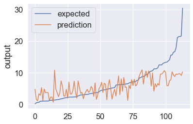

```python
# Plot the chart
chart_regression(MLR_pred.flatten(),test_labels.values.flatten())
```

# Assessing the Quality of Regression Models

## K-fold Cross Validation

"Cross-validation is a process for creating a distribution of pairs of training and test sets out of a single data set. In cross validation the data are partitioned into k subsets, S1…Sk, each called a fold. The folds are usually of approximately the same size. The learning algorithm is then applied k times, for i = 1 to k, each time using the union of all subsets other than Si as the training set and using Si as the test set". (Source: (2011) Cross-Validation. In: Sammut C., Webb G.I. (eds) Encyclopedia of Machine Learning. Springer, Boston, MA. https://doi.org/10.1007/978-0-387-30164-8_190)

```python
from sklearn.model_selection import cross_val_score
from sklearn.model_selection import KFold
from sklearn.model_selection import cross_val_predict
from sklearn.model_selection import cross_validate
import sklearn.metrics as metrics

cv_Kfold = KFold(n_splits=10, random_state=1, shuffle=True)

Xm =mf[['DEM', 'Slope', 'MAT', 'MAP','NDVI']].values
y = mf[['SOC']].values

for i in range(1,11):
    mlr = LinearRegression()
    mlr.fit(Xm, y)
    cv_scores_Kfold = cross_val_score(mlr, Xm, y, scoring="neg_mean_squared_error", cv=cv_Kfold, n_jobs=1)
```

```python
all_scores = pd.DataFrame(cross_validate(mlr, Xm, y, scoring=['r2', 'neg_mean_absolute_error'], n_jobs=-1, verbose=0))
print(all_scores)
```

```
   fit_time  score_time   test_r2  test_neg_mean_absolute_error
0  0.012001    0.001000  0.310929                     -3.639326
1  0.010003    0.001001  0.265494                     -3.101695
2  0.011997    0.001004  0.326416                     -2.331438
3  0.010994    0.001004  0.322108                     -1.805035
4  0.010003    0.000999  0.483584                     -2.947291
```

```python
# mean and STD
print("Folds: " + str(len(cv_scores_Kfold)) + ", MSE: " + str(np.mean(np.abs(cv_scores_Kfold))) + ", STD: " + str(np.std(cv_scores_Kfold)))
```

```
Folds: 10, MSE: 15.076049305815701, STD: 3.034908699379567
```

```python
# Cross-validation prediction
y_pred_KFold = cross_val_predict(mlr, Xm, y, cv=10)
```

```python
Kfold_pred = pd.DataFrame({'Observed': y.flatten(), 'Predicted': y_pred_KFold.flatten()})
Kfold_pred.describe()
```

|  | Observed | Predicted |
| --- | --- | --- |

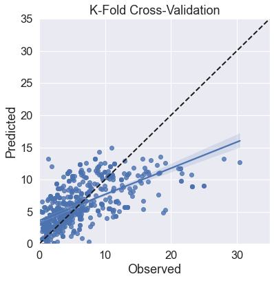

```python
import matplotlib.pyplot as plt
import seaborn as sns

plt.figure(figsize=(6, 6))
ax = sns.regplot(x="Observed", y="Predicted", data=Kfold_pred)
ax.set_ylim(0,35)
ax.set_xlim(0,35)
ax.plot([0, 35], [0, 35], 'k--', lw=2)
plt.title('K-Fold Cross-Validation',fontsize=18)
```

```python
import sklearn.metrics as metrics

print('Mean Absolute Error:', metrics.mean_absolute_error(y, y_pred_KFold))
print('Mean Squared Error:', metrics.mean_squared_error(y, y_pred_KFold))
print('Root Mean Squared Error:', np.sqrt(metrics.mean_squared_error(y, y_pred_KFold)))
print('R2:', metrics.r2_score(y, y_pred_KFold))
```

```
Mean Absolute Error: 2.7864972893328037
Mean Squared Error: 15.407817905098321
Root Mean Squared Error: 3.925279341027632
R2: 0.38507198591757297
```

## Leave-One-Out Cross-Validation¶

Leave-one-out cross-validation is a special case of cross-validation where the number of folds equals the number of instances in the data set. Thus, the learning algorithm is applied once for each instance, using all other instances as a training set and using the selected instance as a single-item test set. This process is closely related to the statistical method of jack-knife estimation (Efron, 1982). (Source:(2011) Leave-One-Out Cross-Validation. In: Sammut C., Webb G.I. (eds) Encyclopedia of Machine Learning. Springer, Boston, MA. https://doi.org/10.1007/978-0-387-30164-8_469).

```python
cv_LOV = KFold(n_splits=570, random_state=None, shuffle=False)
cv_scores_LOV = cross_val_score(mlr, Xm, y, scoring="neg_mean_squared_error", cv=cv_LOV, n_jobs=1)
```

```python
# Mean and SD
print("Folds: " + str(len(cv_scores_LOV)) + ", MSE: " + str(np.mean(np.abs(cv_scores_LOV))) + ", STD: " + str(np.std(cv_scores_LOV)))
```

```
Folds: 570, MSE: 15.002241515906006, STD: 32.719031175541524
```

```python
# Prediction
y_pred_LOV = cross_val_predict(mlr, Xm, y, cv=10)
```

```python
LOV_pred = pd.DataFrame({'Observed': y.flatten(), 'Predicted': y_pred_LOV.flatten()})
LOV_pred.describe()
```

|  | Observed | Predicted |
| --- | --- | --- |

[figure not shown]

```python
plt.figure(figsize=(6, 6))
ax = sns.regplot(x="Observed", y="Predicted", data=LOV_pred)
ax.set_ylim(0,35)
ax.set_xlim(0,35)
ax.plot([0, 35], [0, 35], 'k--', lw=2)
plt.title('LOV Cross-Validation',fontsize=18)
```

## Prediction at test locations (hold-out data set)

Now that we have trained our algorithm, it’s time to make some predictions. To do so, we will use our test data and see how accurately SRL predicts the SOC

```python
y_mlr_pred = mlr.predict(x_test)
```

```python
mlr_pred = pd.DataFrame({'Observed': y_test.flatten(), 'Predicted': y_mlr_pred.flatten()})
mlr_pred.describe()
```

|  | Observed | Predicted |
| --- | --- | --- |

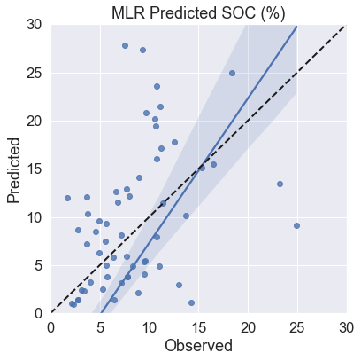

```python
import matplotlib.pyplot as plt
import seaborn as sns

plt.figure(figsize=(6, 6))
ax = sns.regplot(x="Observed", y="Predicted", data=mlr_pred)
ax.set_ylim(0,30)
ax.set_xlim(0,30)
ax.plot([0, 30], [0, 30], 'k--', lw=2)
plt.title('MLR Predicted SOC (%)',fontsize=18)
```